# Matplotlib

# Examining a specific data range

Sometimes you want to enhance the contrast in your image, or expand the contrast in a particular region while sacrificing the detail in colors that don't vary much, or don't matter. A good tool to find interesting regions is the histogram. To create a histogram of our image data, we use the hist() function.

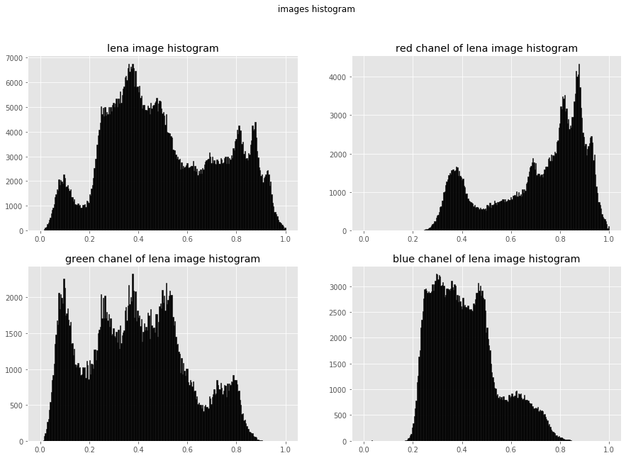

```python
figure(num=None, figsize=(15, 10))

plt.subplot(2, 2, 1)
plt.hist(img_lena.ravel(), bins=256, range=(0.0, 1.0), fc='k', ec='k')
plt.title("lena image histogram")

plt.subplot(2, 2, 2)
plt.hist(red_img_lena.ravel(), bins=256, range=(0.0, 1.0), fc='k', ec='k')
plt.title("red chanel of lena image histogram")

plt.subplot(2, 2, 3)
plt.hist(green_img_lena.ravel(), bins=256, range=(0.0, 1.0), fc='k', ec='k')
plt.title("green chanel of lena image histogram")

plt.subplot(2, 2, 4)
plt.hist(blue_img_lena.ravel(), bins=256, range=(0.0, 1.0), fc='k', ec='k')
plt.title("blue chanel of lena image histogram")

plt.suptitle(" images histogram")
plt.show()
```

In color images, we have 3 color channels representing RGB. In Combined Color Histogram the intensity count is the sum of all three color channels.

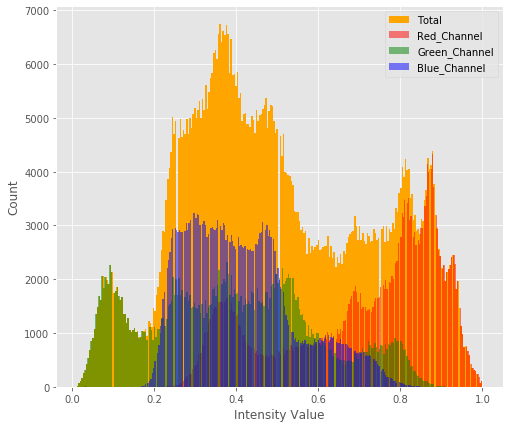

```python
import matplotlib.pyplot as plt
image = plt.imread('lena.png')

_ = plt.hist(image.ravel(), bins = 256, color = 'orange', )
_ = plt.hist(image[:, :, 0].ravel(), bins = 256, color = 'red', alpha = 0.5)
_ = plt.hist(image[:, :, 1].ravel(), bins = 256, color = 'Green', alpha = 0.5)
_ = plt.hist(image[:, :, 2].ravel(), bins = 256, color = 'Blue', alpha = 0.5)
_ = plt.xlabel('Intensity Value')
_ = plt.ylabel('Count')
_ = plt.legend(['Total', 'Red_Channel', 'Green_Channel', 'Blue_Channel'])
plt.show()
```

# Histogram equalization

Histogram equalization is a method in image processing of contrast adjustment using the image's histogram.

[figure not shown]

```python
# Importing Image and ImageOps module from PIL package
from PIL import Image, ImageOps
im1 = Image.open(r"lena.png")
im2 = ImageOps.equalize(im1, mask = None)
plt.imshow(im2)
```

# scikit-image

scikit-image is a collection of algorithms for image processing.

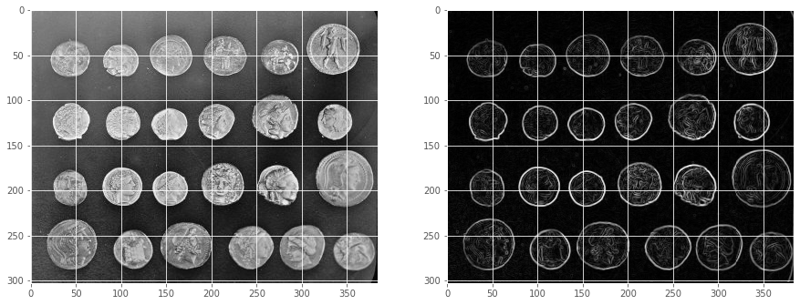

```python
from skimage import data,filters

figure(num=None, figsize=(15, 10))

img_coin = data.coins()
edges_coin = filters.sobel(img_coin)
plt.subplot(1, 2, 1)
plt.imshow(img_coin, cmap='gray')
plt.subplot(1, 2, 2)
plt.imshow(edges_coin, cmap='gray')
```

# NumPy

[figure not shown]

```python
figure(num=None, figsize=(15, 10))

image_camera = data.camera()

plt.subplot(1, 2, 1)
plt.imshow(image_camera, cmap='gray')


mask_camera = image_camera < 87
image_camera[mask_camera]=255
plt.subplot(1, 2, 2)

plt.imshow(image_camera, cmap='gray')
```

# Using SciPy for blurring using a Gaussian filter:

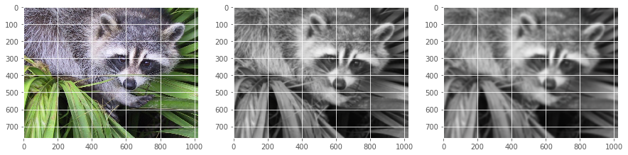

```python
from scipy import misc,ndimage
figure(num=None, figsize=(15, 10))

ime_face = misc.face()
blurred_face = ndimage.gaussian_filter(ime_face, sigma=3)
very_blurred = ndimage.gaussian_filter(ime_face, sigma=5)
plt.subplot(1, 3, 1)
plt.imshow(ime_face)
plt.subplot(1, 3, 2)
plt.imshow(blurred_face)
plt.subplot(1, 3, 3)
plt.imshow(very_blurred)
```

# exciting small project

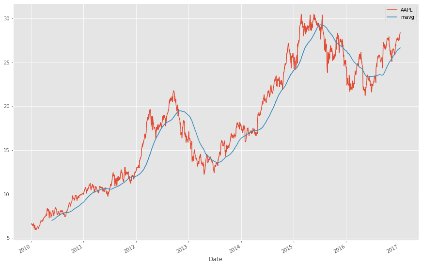

```python
import pandas as pd
import datetime
import pandas_datareader.data as web
from pandas import Series, DataFrame
figure(num=None, figsize=(15, 10))


start = datetime.datetime(2010, 1, 1)
end = datetime.datetime(2017, 1, 11)

df = web.DataReader("AAPL", 'yahoo', start, end)
close_px = df['Adj Close']
mavg = close_px.rolling(window=100).mean()

from matplotlib import style

# Adjusting the size of matplotlib
import matplotlib as mpl
mpl.rc('figure', figsize=(8, 7))
mpl.__version__

# Adjusting the style of matplotlib
style.use('ggplot')

close_px.plot(label='AAPL')
mavg.plot(label='mavg')
plt.legend()
```